# Exercise

Ricardo Landolt

2022-06-08

### Overiew

the structure of data seems that the right datatypes have been used

```r
str(df)
```

```
## 'data.frame':    490 obs. of  12 variables:
##  $ State        : chr  "Alabama" "Alabama" "Alabama" "Alabama" ...
##  $ StateID      : int  1 1 1 1 1 1 1 1 1 1 ...
##  $ Year         : int  1985 1986 1987 1988 1989 1990 1991 1992 1993 1994 ...
##  $ MurderPer100K: num  9.8 10.1 9.3 9.9 10.2 ...
##  $ DeathPenalty : int  1 1 1 1 1 1 1 1 1 1 ...
##  $ Population   : int  4021 4051 4084 4102 4030 4041 4089 4131 4181 4219 ...
##  $ UrbanPct     : num  60 60 60 60 60 ...
##  $ AvgEducation : num  11.6 11.7 11.8 11.9 12 ...
##  $ SchoolSpendEq: int  89 89 89 89 89 89 89 89 89 89 ...
##  $ AvgIdeol     : num  33.3 34.8 34.8 36 36 ...
##  $ CitizenIdeol : num  27.9 37.8 38.5 45 37.5 ...
##  $ EliteIdeol   : num  38.4 49.8 34.4 40.9 31.7 ...
```

summary statistic looks normal, no obvious outliers

```r
summary(df)
```

```
##     State              StateID           Year      MurderPer100K
##  Length:490         Min.   : 1.00   Min.   :1985   Min.   : 0.200
##  Class :character   1st Qu.:13.00   1st Qu.:1987   1st Qu.: 3.800
##  Mode  :character   Median :25.00   Median :1990   Median : 6.300
##                     Mean   :25.47   Mean   :1990   Mean   : 6.908
##                     3rd Qu.:38.00   3rd Qu.:1992   3rd Qu.:10.100
##                     Max.   :50.00   Max.   :1994   Max.   :20.300
##   DeathPenalty      Population       UrbanPct      AvgEducation
##  Min.   :0.0000   Min.   :  454   Min.   :33.80   Min.   :11.48
##  1st Qu.:0.0000   1st Qu.: 1236   1st Qu.:57.80   1st Qu.:12.50
##  Median :1.0000   Median : 3466   Median :68.85   Median :12.88
##  Mean   :0.7347   Mean   : 5034   Mean   :68.93   Mean   :12.81
##  3rd Qu.:1.0000   3rd Qu.: 5960   3rd Qu.:83.30   3rd Qu.:13.16
##  Max.   :1.0000   Max.   :31431   Max.   :93.70   Max.   :13.89
##  SchoolSpendEq       AvgIdeol      CitizenIdeol     EliteIdeol
##  Min.   : 65.00   Min.   : 9.49   Min.   :16.34   Min.   : 1.667
##  1st Qu.: 75.00   1st Qu.:35.50   1st Qu.:39.11   1st Qu.:40.619
##  Median : 81.00   Median :42.38   Median :48.24   Median :56.181
##  Mean   : 80.37   Mean   :43.98   Mean   :50.01   Mean   :55.175
##  3rd Qu.: 86.00   3rd Qu.:51.29   3rd Qu.:59.88   3rd Qu.:72.047
##  Max.   :100.00   Max.   :82.21   Max.   :93.91   Max.   :95.750
```

the hist plot shows that it is a balanced dataset

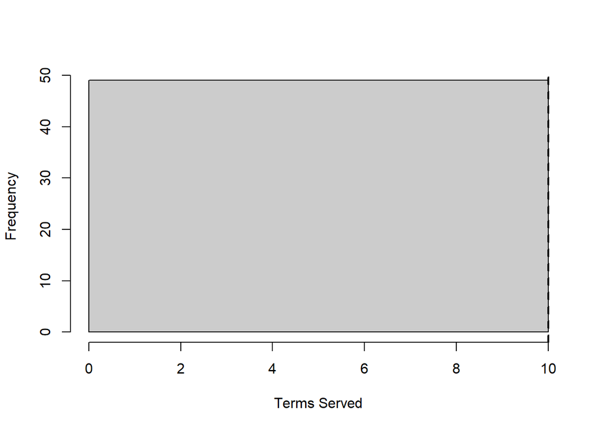

```r
dfyear<-ddply(df,.(StateID),summarise,
             Terms=n())

hist(dfyear$Terms,col="grey80",freq=TRUE,
     main="",xlab="Terms Served")
abline(v=mean(dfyear$Terms),lwd=2,lty=2)
```

there are no missing values

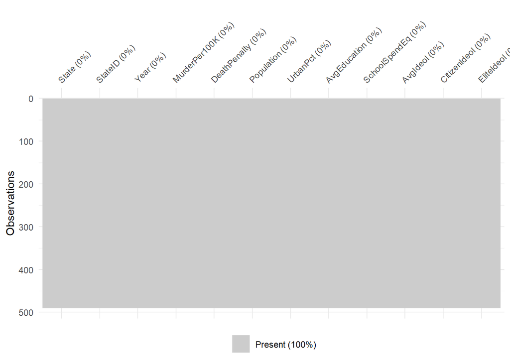

```r
vis_miss(df)
```

### Between and within Variation

#### MurderPer100K

the between variation is quite as high as the total variation. But there is also some within variation.

```r
pddf <- pdata.frame(df, index = c("StateID", "Year"))
murder <- pddf$MurderPer100K

describe(murder,na.rm=TRUE)
```

```
##    vars   n mean   sd median trimmed mad min  max range skew kurtosis   se
## X1    1 490 6.91 3.66    6.3    6.77 4.3 0.2 20.3  20.1 0.43    -0.38 0.17
```

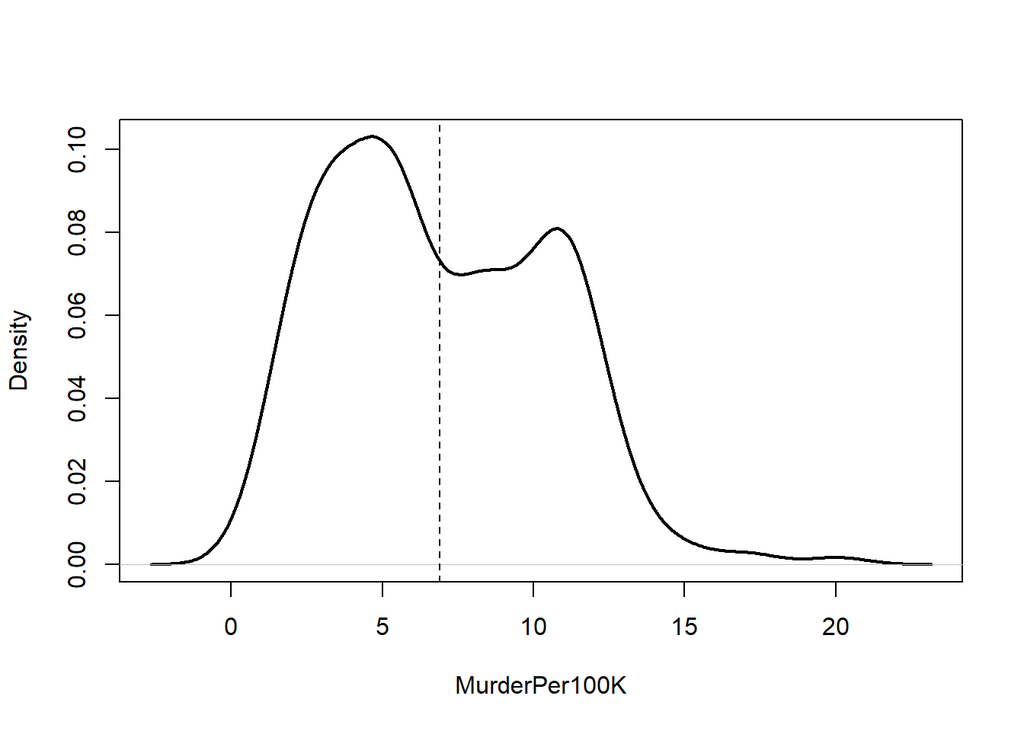

```r
plot(density(pddf$MurderPer100K,na.rm=TRUE),
     main="",xlab="MurderPer100K",lwd=2)
abline(v=mean(pddf$MurderPer100K,na.rm=TRUE),
       lwd=1,lty=2)
```

```r
describe(plm::between(murder,effect="individual",na.rm=TRUE)) # "between" variation
```

```
##    vars  n mean   sd median trimmed  mad  min   max range skew kurtosis   se
## X1    1 49 6.91 3.54   5.98    6.81 4.69 1.16 15.29 14.13 0.24    -1.09 0.51
```

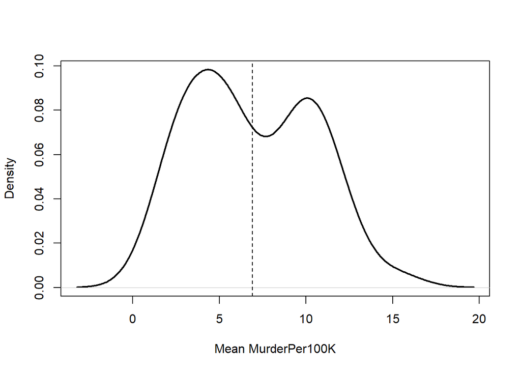

```r
murderMeans<-plm::between(murder,effect="individual",na.rm=TRUE)


plot(density(murderMeans,na.rm=TRUE),
     main="",xlab="Mean MurderPer100K",lwd=2)
abline(v=mean(murderMeans,na.rm=TRUE),
       lwd=1,lty=2)
```

```r
describe(Within(murder,na.rm=TRUE)) # "within" variation
```

```
##    vars   n mean   sd median trimmed mad   min  max range skew kurtosis   se
## X1    1 490    0 1.04  -0.02       0 0.9 -4.39 5.01   9.4 0.07     2.67 0.05
```

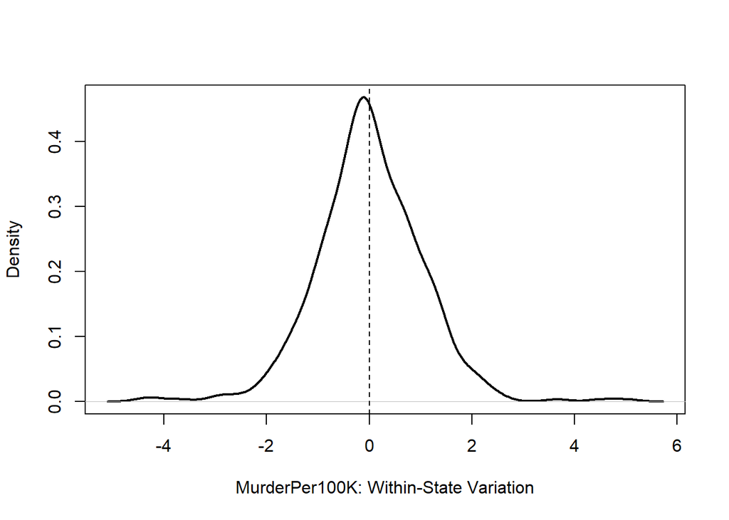

```r
plot(density(Within(murder,na.rm=TRUE),na.rm=TRUE),
     main="",xlab="MurderPer100K: Within-State Variation",
     lwd=2)
abline(v=0,lty=2)
```

#### UrbanPct

variation between states is nearly like the total variation within varation is quite small and so over the time consistently

```r
with(df, describe(UrbanPct))
```

```
##    vars   n  mean    sd median trimmed   mad  min  max range  skew kurtosis
## X1    1 490 68.93 14.53  68.85   69.43 17.64 33.8 93.7  59.9 -0.23    -0.83
##      se
## X1 0.66
```

```r
LibMeans <- ddply(df,.(StateID),summarise,
                MeanLibPct=mean(UrbanPct))
with(LibMeans, describe(MeanLibPct))
```

```
##    vars  n  mean    sd median trimmed   mad min  max range  skew kurtosis   se
## X1    1 49 68.93 14.45  68.75   69.39 19.94  37 92.5  55.5 -0.21    -0.99 2.06
```

```r
dfw <- ddply(df,.(StateID), mutate,
             LibMean=mean(UrbanPct))
dfw$LibWithin <- with(dfw, UrbanPct-LibMean)
with(dfw, describe(LibWithin))
```

```
##    vars   n mean   sd median trimmed  mad   min  max range skew kurtosis   se
## X1    1 490    0 2.48      0       0 2.97 -5.35 5.35  10.7    0    -0.96 0.11
```

#### AvgEducation

variation between states is nearly like the total variation within varation is quite small and so over the time consistently

```r
with(df, describe(AvgEducation))
```

```
##    vars   n  mean   sd median trimmed  mad   min   max range  skew kurtosis
## X1    1 490 12.81 0.49  12.88   12.84 0.47 11.48 13.89   2.4 -0.48    -0.15
##      se
## X1 0.02
```

```r
LibMeans <- ddply(df,.(StateID),summarise,
                MeanLibPct=mean(AvgEducation))
with(LibMeans, describe(MeanLibPct))
```

```
##    vars  n  mean   sd median trimmed  mad   min   max range  skew kurtosis   se
## X1    1 49 12.81 0.42  12.87   12.83 0.36 11.95 13.54  1.58 -0.55    -0.55 0.06
```

```r
dfw <- ddply(df,.(StateID), mutate,
             LibMean=mean(AvgEducation))
dfw$LibWithin <- with(dfw, AvgEducation-LibMean)
with(dfw, describe(LibWithin))
```

```
##    vars   n mean   sd median trimmed  mad   min  max range skew kurtosis   se
## X1    1 490    0 0.27      0       0 0.32 -0.64 0.65   1.3 0.01    -0.84 0.01
```

#### SchoolSpendEq

variation between states is high like the total variation within varation is zero

```r
with(df, describe(SchoolSpendEq))
```

```
##    vars   n  mean   sd median trimmed mad min max range  skew kurtosis   se
## X1    1 490 80.37 7.99     81    80.6 8.9  65 100    35 -0.17    -0.39 0.36
```

```r
LibMeans <- ddply(df,.(StateID),summarise,
                MeanLibPct=mean(SchoolSpendEq))
with(LibMeans, describe(MeanLibPct))
```

```
##    vars  n  mean   sd median trimmed mad min max range  skew kurtosis   se
## X1    1 49 80.37 8.06     81   80.51 8.9  65 100    35 -0.17    -0.49 1.15
```

```r
dfw <- ddply(df,.(StateID), mutate,
             LibMean=mean(SchoolSpendEq))
dfw$LibWithin <- with(dfw, SchoolSpendEq-LibMean)
with(dfw, describe(LibWithin))
```

```
##    vars   n mean sd median trimmed mad min max range skew kurtosis se
## X1    1 490    0  0      0       0   0   0   0     0  NaN      NaN  0
```

#### AvgIdeol

variation between states is nearly like the total variation within varation is quite small and so over the time consistently

```r
with(df, describe(AvgIdeol))
```

```
##    vars   n  mean    sd median trimmed   mad  min   max range skew kurtosis
## X1    1 490 43.98 15.28  42.38   43.17 11.34 9.49 82.21 72.72 0.47      0.1
##      se
## X1 0.69
```

```r
LibMeans <- ddply(df,.(StateID),summarise,
                MeanLibPct=mean(AvgIdeol))
with(LibMeans, describe(MeanLibPct))
```

```
##    vars  n  mean    sd median trimmed   mad   min   max range skew kurtosis  se
## X1    1 49 43.98 14.69  41.94   43.32 10.51 12.97 77.94 64.97 0.51     0.13 2.1
```

```r
dfw <- ddply(df,.(StateID), mutate,
             LibMean=mean(AvgIdeol))
dfw$LibWithin <- with(dfw, AvgIdeol-LibMean)
with(dfw, describe(LibWithin))
```

```
##    vars   n mean   sd median trimmed  mad    min   max range skew kurtosis   se
## X1    1 490    0 4.64  -0.02   -0.06 3.15 -24.51 26.62 51.14 0.33     4.86 0.21
```

#### CitizenIdeol

variation between states is nearly like the total variation within varation is quite small and so over the time consistently

```r
with(df, describe(CitizenIdeol))
```

```
##    vars   n  mean    sd median trimmed   mad   min   max range skew kurtosis
## X1    1 490 50.01 14.43  48.24   49.27 14.88 16.34 93.91 77.57 0.47     -0.2
##      se
## X1 0.65
```

```r
LibMeans <- ddply(df,.(StateID),summarise,
                MeanLibPct=mean(CitizenIdeol))
with(LibMeans, describe(MeanLibPct))
```

```
##    vars  n  mean    sd median trimmed   mad   min   max range skew kurtosis
## X1    1 49 50.01 13.46   47.9   49.32 15.83 27.12 84.37 57.24 0.47     -0.7
##      se
## X1 1.92
```

```r
dfw <- ddply(df,.(StateID), mutate,
             LibMean=mean(CitizenIdeol))
dfw$LibWithin <- with(dfw, CitizenIdeol-LibMean)
with(dfw, describe(LibWithin))
```

```
##    vars   n mean  sd median trimmed  mad   min   max range  skew kurtosis   se
## X1    1 490    0 5.5   0.15    0.03 5.18 -23.1 19.76 42.87 -0.09     0.63 0.25
```

#### EliteIdeol

```r
with(df, describe(EliteIdeol))
```

```
##    vars   n  mean    sd median trimmed   mad  min   max range skew kurtosis
## X1    1 490 55.18 21.44  56.18   56.11 23.27 1.67 95.75 94.08 -0.3    -0.59
##      se
## X1 0.97
```

```r
LibMeans <- ddply(df,.(StateID),summarise,
                MeanLibPct=mean(EliteIdeol))
with(LibMeans, describe(MeanLibPct))
```

```
##    vars  n  mean    sd median trimmed   mad  min   max range  skew kurtosis  se
## X1    1 49 55.18 18.17  54.37      56 16.06 7.47 86.22 78.75 -0.35    -0.18 2.6
```

```r
dfw <- ddply(df,.(StateID), mutate,
             LibMean=mean(EliteIdeol))
dfw$LibWithin <- with(dfw, EliteIdeol-LibMean)
with(dfw, describe(LibWithin))
```

```
##    vars   n mean    sd median trimmed   mad    min   max range  skew kurtosis
## X1    1 490    0 11.65   0.83    0.34 10.32 -40.73 28.68 69.41 -0.33     0.35
##      se
## X1 0.53
```

### Panel Data Visualiszation

most of the states are on the same level during over the years. A few states have a upward trend.

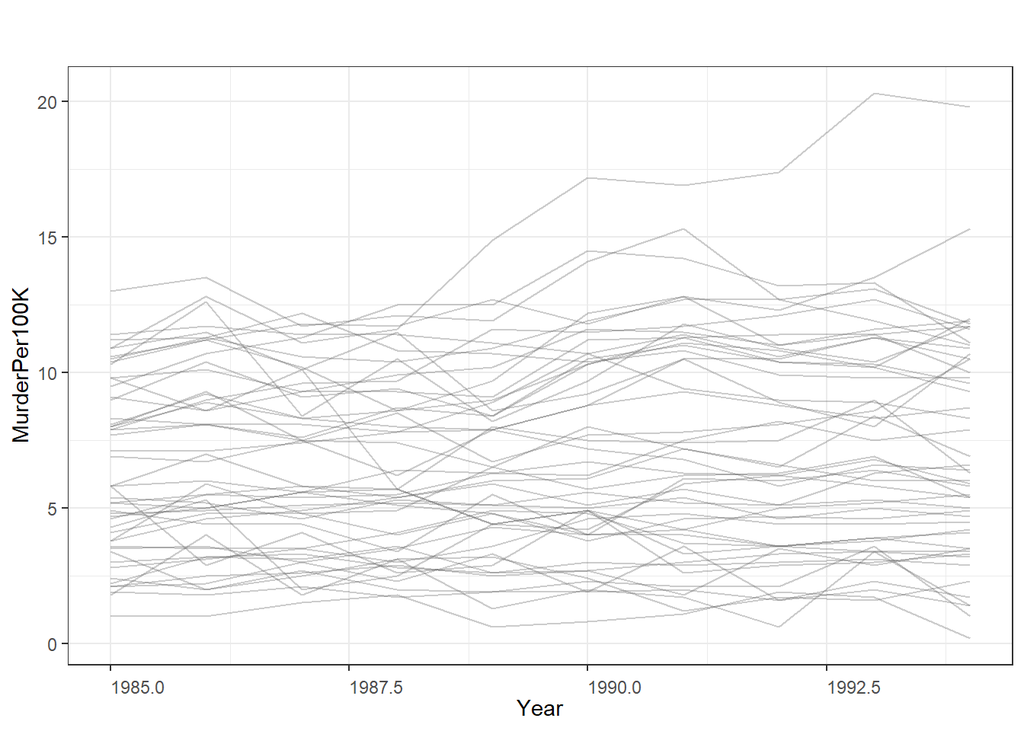

```r
panelview(MurderPer100K~1,data=df,theme.bw=TRUE,
          outcome.type="continuous",type="outcome",
          by.timing=TRUE,index=c("StateID","Year"),
          main=" ",ylab="MurderPer100K",
          legendOff=TRUE)
```

overtime no state changed their deathpenalty and their are more states with deathpenalty

```r
panelview(MurderPer100K~DeathPenalty,data=df,theme.bw=TRUE,
          by.timing=FALSE,index=c("StateID","Year"),
          color=c("orange","darkgreen"),
          legend.labs=c("No DeathPenalty","DeathPenalty"),
          main=" ",ylab="State Code",axis.lab.gap=c(5,5),
          background="white")
```

```
## Specified colors in the order of: Under Control, Under Treatment.
## Specified labels in the order of: Under Control, Under Treatment.
```

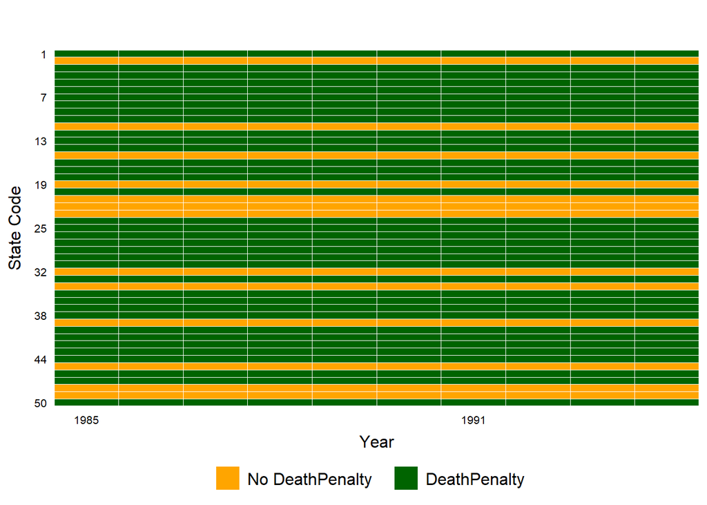

### Modeling

Expectation is that the MurderPer100K Variabel increases if the Population, UrbanPct increase or AvgEducation, AvgIdeol decrease.

#### Pooled OLS

The expectations are met in the ols model

```r
OLS<-plm(MurderPer100K~DeathPenalty+log(Population)+UrbanPct+AvgEducation+AvgIdeol ,
        data=pddf, model="pooling")

summary(OLS)
```

```
## Pooling Model
##
## Call:
## plm(formula = MurderPer100K ~ DeathPenalty + log(Population) +
##     UrbanPct + AvgEducation + AvgIdeol, data = pddf, model = "pooling")
##
## Balanced Panel: n = 49, T = 10, N = 490
##
## Residuals:
##     Min.  1st Qu.   Median  3rd Qu.     Max.
## -5.95303 -2.10421 -0.43534  1.53200 11.55299
##
## Coefficients:
##                   Estimate Std. Error t-value  Pr(>|t|)
## (Intercept)     19.6168474  4.2629598  4.6017 5.360e-06 ***
## DeathPenalty     1.6514946  0.3316729  4.9793 8.892e-07 ***
## log(Population)  1.3891750  0.1560211  8.9038 < 2.2e-16 ***
## UrbanPct         0.0420808  0.0121208  3.4718 0.0005633 ***
## AvgEducation    -2.1681584  0.3088367 -7.0204 7.520e-12 ***
## AvgIdeol        -0.0052149  0.0096358 -0.5412 0.5886210
## ---
## Signif. codes:  0 '***' 0.001 '**' 0.01 '*' 0.05 '.' 0.1 ' ' 1
##
## Total Sum of Squares:    6539.2
## Residual Sum of Squares: 3798.8
## R-Squared:      0.41908
## Adj. R-Squared: 0.41308
## F-statistic: 69.8313 on 5 and 484 DF, p-value: < 2.22e-16
```

#### Fixed Effect within unit

DeathPenalty and SchoolSpendEq (SchoolSpendEq removed in the model) are for all the years the same within a unit/state and drops away. The expectations are not met in the Fixed Effect model, for example AvgEducation has totally different effect as expected.Further, $r^{2}$ is very low.

```r
FE<-plm(MurderPer100K~DeathPenalty+log(Population)+UrbanPct+AvgEducation+AvgIdeol ,
        data=pddf, effect="individual",model="within")
summary(FE)
```

```
## Oneway (individual) effect Within Model
##
## Call:
## plm(formula = MurderPer100K ~ DeathPenalty + log(Population) +
##     UrbanPct + AvgEducation + AvgIdeol, data = pddf, effect = "individual",
##     model = "within")
##
## Balanced Panel: n = 49, T = 10, N = 490
##
## Residuals:
##       Min.    1st Qu.     Median    3rd Qu.       Max.
## -3.6309017 -0.5995844  0.0022583  0.5700982  4.3534560
##
## Coefficients:
##                    Estimate  Std. Error t-value  Pr(>|t|)
## log(Population) -4.71180752  1.43177076 -3.2909   0.00108 **
## UrbanPct         0.03252765  0.02490903  1.3059   0.19229
## AvgEducation     1.47280634  0.25722835  5.7257 1.918e-08 ***
## AvgIdeol        -0.00035249  0.01021321 -0.0345   0.97248
## ---
## Signif. codes:  0 '***' 0.001 '**' 0.01 '*' 0.05 '.' 0.1 ' ' 1
##
## Total Sum of Squares:    527.15
## Residual Sum of Squares: 458.25
## R-Squared:      0.13071
## Adj. R-Squared: 0.027265
## F-statistic: 16.4266 on 4 and 437 DF, p-value: 1.5089e-12
```

#### Fixed Effect within time

The expectations are met in this Fixed Effect model within the different time points and also the $r^{2}$ imporved and is over the ols model.

```r
FE.Time<-plm(MurderPer100K~DeathPenalty+log(Population)+UrbanPct+AvgEducation+AvgIdeol ,
        data=pddf,effect="time",model="within")
summary(FE.Time)
```

```
## Oneway (time) effect Within Model
##
## Call:
## plm(formula = MurderPer100K ~ DeathPenalty + log(Population) +
##     UrbanPct + AvgEducation + AvgIdeol, data = pddf, effect = "time",
##     model = "within")
##
## Balanced Panel: n = 49, T = 10, N = 490
##
## Residuals:
##    Min. 1st Qu.  Median 3rd Qu.    Max.
## -4.7261 -1.9018 -0.2948  1.6361  9.5127
##
## Coefficients:
##                   Estimate Std. Error  t-value  Pr(>|t|)
## DeathPenalty     1.3926641  0.3173902   4.3879 1.411e-05 ***
## log(Population)  1.1117672  0.1532062   7.2567 1.628e-12 ***
## UrbanPct         0.0638897  0.0119520   5.3455 1.403e-07 ***
## AvgEducation    -3.7155778  0.3584831 -10.3647 < 2.2e-16 ***
## AvgIdeol        -0.0124714  0.0092186  -1.3529    0.1767
## ---
## Signif. codes:  0 '***' 0.001 '**' 0.01 '*' 0.05 '.' 0.1 ' ' 1
##
## Total Sum of Squares:    6479.4
## Residual Sum of Squares: 3372.4
## R-Squared:      0.47953
## Adj. R-Squared: 0.46418
## F-statistic: 87.5256 on 5 and 475 DF, p-value: < 2.22e-16
```

#### Between Model

The same is true is for the between model.

```r
BE<-plm(MurderPer100K~DeathPenalty+log(Population)+UrbanPct+AvgEducation+AvgIdeol ,
        data=pddf,effect="individual",model="between")

summary(BE)
```

```
## Oneway (individual) effect Between Model
##
## Call:
## plm(formula = MurderPer100K ~ DeathPenalty + log(Population) +
##     UrbanPct + AvgEducation + AvgIdeol, data = pddf, effect = "individual",
##     model = "between")
##
## Balanced Panel: n = 49, T = 10, N = 490
## Observations used in estimation: 49
##
## Residuals:
##      Min.   1st Qu.    Median   3rd Qu.      Max.
## -4.047924 -1.932662 -0.092237  1.131721  6.639150
##
## Coefficients:
##                  Estimate Std. Error t-value  Pr(>|t|)
## (Intercept)     45.064071  15.305874  2.9442 0.0052044 **
## DeathPenalty     1.275222   0.977540  1.3045 0.1989948
## log(Population)  1.050115   0.468329  2.2423 0.0301553 *
## UrbanPct         0.071622   0.037125  1.9292 0.0603180 .
## AvgEducation    -4.036632   1.112937 -3.6270 0.0007554 ***
## AvgIdeol        -0.017669   0.029866 -0.5916 0.5572102
## ---
## Signif. codes:  0 '***' 0.001 '**' 0.01 '*' 0.05 '.' 0.1 ' ' 1
##
## Total Sum of Squares:    601.21
## Residual Sum of Squares: 280.19
## R-Squared:      0.53395
## Adj. R-Squared: 0.47976
## F-statistic: 9.8529 on 5 and 43 DF, p-value: 2.5081e-06
```

#### Random Model

The random effect model tends to the fixed effect model, the coefficients look not as expected.

```r
RE<-plm(MurderPer100K~DeathPenalty+log(Population)+UrbanPct+AvgEducation+AvgIdeol ,
        data=pddf,
        effect="individual",model="random")

summary(RE)
```

```
## Oneway (individual) effect Random Effect Model
##    (Swamy-Arora's transformation)
##
## Call:
## plm(formula = MurderPer100K ~ DeathPenalty + log(Population) +
##     UrbanPct + AvgEducation + AvgIdeol, data = pddf, effect = "individual",
##     model = "random")
##
## Balanced Panel: n = 49, T = 10, N = 490
##
## Effects:
##                 var std.dev share
## idiosyncratic 1.049   1.024 0.141
## individual    6.411   2.532 0.859
## theta: 0.8731
##
## Residuals:
##     Min.  1st Qu.   Median  3rd Qu.     Max.
## -2.99016 -0.70616 -0.16835  0.61827  5.67441
##
## Coefficients:
##                    Estimate  Std. Error z-value  Pr(>|z|)
## (Intercept)     -18.4619683   3.7045358 -4.9836 6.241e-07 ***
## DeathPenalty      2.2104669   0.8894051  2.4853   0.01294 *
## log(Population)   1.3943168   0.3908093  3.5678   0.00036 ***
## UrbanPct          0.0234125   0.0204251  1.1463   0.25169
## AvgEducation      0.8431543   0.2146395  3.9282 8.557e-05 ***
## AvgIdeol          0.0026181   0.0099984  0.2619   0.79344
## ---
## Signif. codes:  0 '***' 0.001 '**' 0.01 '*' 0.05 '.' 0.1 ' ' 1
##
## Total Sum of Squares:    623.9
## Residual Sum of Squares: 546.97
## R-Squared:      0.12331
## Adj. R-Squared: 0.11425
## Chisq: 68.0774 on 5 DF, p-value: 2.5734e-13
```

#### Twoway Model within

The twoway unit effect model within or random looks also not promising

```r
TwoWayFE<-plm(MurderPer100K~log(Population)+UrbanPct+AvgEducation+AvgIdeol + DeathPenalty ,
              data=pddf,effect="twoway",model="within")

summary(TwoWayFE)
```

```
## Twoways effects Within Model
##
## Call:
## plm(formula = MurderPer100K ~ log(Population) + UrbanPct + AvgEducation +
##     AvgIdeol + DeathPenalty, data = pddf, effect = "twoway",
##     model = "within")
##
## Balanced Panel: n = 49, T = 10, N = 490
##
## Residuals:
##      Min.   1st Qu.    Median   3rd Qu.      Max.
## -3.556973 -0.605943  0.013554  0.580158  4.206350
##
## Coefficients:
##                   Estimate Std. Error t-value  Pr(>|t|)
## log(Population) -2.8554481  1.4938541 -1.9115   0.05661 .
## UrbanPct         0.0181047  0.0292296  0.6194   0.53599
## AvgEducation     4.1623012  0.7651488  5.4399 8.987e-08 ***
## AvgIdeol        -0.0061168  0.0102073 -0.5993   0.54932
## ---
## Signif. codes:  0 '***' 0.001 '**' 0.01 '*' 0.05 '.' 0.1 ' ' 1
##
## Total Sum of Squares:    467.32
## Residual Sum of Squares: 429.2
## R-Squared:      0.081569
## Adj. R-Squared: -0.049329
## F-statistic: 9.50307 on 4 and 428 DF, p-value: 2.2807e-07
```

#### Twoway Model Random

```r
TwoWayRE<-plm(MurderPer100K~log(Population)+UrbanPct+AvgEducation+AvgIdeol + DeathPenalty , data=pddf,
              effect="twoway",model="random")

summary(TwoWayRE)
```

```
## Twoways effects Random Effect Model
##    (Swamy-Arora's transformation)
##
## Call:
## plm(formula = MurderPer100K ~ log(Population) + UrbanPct + AvgEducation +
##     AvgIdeol + DeathPenalty, data = pddf, effect = "twoway",
##     model = "random")
##
## Balanced Panel: n = 49, T = 10, N = 490
##
## Effects:
##                   var std.dev share
## idiosyncratic 1.00281 1.00140 0.135
## individual    6.41587 2.53296 0.863
## time          0.01695 0.13020 0.002
## theta: 0.8759 (id) 0.2604 (time) 0.2597 (total)
##
## Residuals:
##     Min.  1st Qu.   Median  3rd Qu.     Max.
## -2.97632 -0.70215 -0.16487  0.60929  5.61671
##
## Coefficients:
##                    Estimate  Std. Error z-value  Pr(>|z|)
## (Intercept)     -19.4826437   4.2485268 -4.5857 4.524e-06 ***
## log(Population)   1.4541037   0.3969972  3.6628 0.0002495 ***
## UrbanPct          0.0131766   0.0211799  0.6221 0.5338588
## AvgEducation      0.9371845   0.2613279  3.5862 0.0003355 ***
## AvgIdeol          0.0029678   0.0099314  0.2988 0.7650737
## DeathPenalty      2.2451848   0.8997971  2.4952 0.0125882 *
## ---
## Signif. codes:  0 '***' 0.001 '**' 0.01 '*' 0.05 '.' 0.1 ' ' 1
##
## Total Sum of Squares:    592.57
## Residual Sum of Squares: 535.89
## R-Squared:      0.09565
## Adj. R-Squared: 0.086308
## Chisq: 51.1912 on 5 DF, p-value: 7.9026e-10
```

### Testing

The F-Tests imply that there are time as unit effects, as expected like before in the decomposition of the variation. The Hausman test imply tha one model is inconsistent, which is propably due to the non-time-varying covariate effects.

```r
pFtest(FE.Time, OLS)
```

```
##
##  F test for time effects
##
## data:  MurderPer100K ~ DeathPenalty + log(Population) + UrbanPct + AvgEducation +  ...
## F = 6.6736, df1 = 9, df2 = 475, p-value = 5.123e-09
## alternative hypothesis: significant effects
```

```r
pFtest(FE, OLS)
```

```
##
##  F test for individual effects
##
## data:  MurderPer100K ~ DeathPenalty + log(Population) + UrbanPct + AvgEducation +  ...
## F = 67.78, df1 = 47, df2 = 437, p-value < 2.2e-16
## alternative hypothesis: significant effects
```

```r
phtest(FE, RE)
```

```
##
##  Hausman Test
##
## data:  MurderPer100K ~ DeathPenalty + log(Population) + UrbanPct + AvgEducation +  ...
## chisq = 10.778, df = 4, p-value = 0.02917
## alternative hypothesis: one model is inconsistent
```